# DSE 511 Final Project: Exploratory Data Analysis

Cecilia Albert-Black

2025-11-07

Set working directory to R code folder

```r
setwd("C:/Users/q4q/repos/DSE511_Final_Project/Step 2. Exploratory Data Analysis/R Code")
```

Load necessary libraries

```r
library(readr)
library(tidyverse)
library(skimr)
library(scales)
```

## Exploratory Data Analysis of Clean Dataset

Import dataset from Step 1. Data Cleaning

```r
clean_df <- read_csv("C:/Users/q4q/repos/DSE511_Final_Project/Step 1. Data Cleaning/R code/outbreak_clean_r_v2.csv")
head(clean_df)
```

```
## # A tibble: 6 × 30
##    Year Month Date    Season State      State_abbr Primary_mode Setting Etiology
##   <dbl> <dbl> <chr>   <chr>  <chr>      <chr>      <chr>        <chr>   <chr>
## 1  1971     2 1971-02 Winter California CA         Water        Restau… Copper
## 2  1971     6 1971-06 Summer Arkansas   AR         Water        Store   Hepatit…
## 3  1971     6 1971-06 Summer Missouri   MO         Water        Subdiv… Unknown
## 4  1971     6 1971-06 Summer Alabama    AL         Water        Unknown Selenium
## 5  1971     6 1971-06 Summer Vermont    VT         Water        Commun… Unknown
## 6  1971     6 1971-06 Summer Oregon     OR         Water        Restau… Unknown
## # ℹ 21 more variables: Etiology_group <chr>, IFSAC_category <chr>,
## #   Food_vehicle <chr>, Water_exposure <chr>, Water_type <chr>,
## #   Water_type_group <chr>, Animal_type <chr>, Animal_type_group <chr>,
## #   Illnesses <dbl>, Hospitalizations <dbl>, Deaths <dbl>,
## #   Hospitalizations_std <dbl>, Deaths_std <dbl>, Illnesses_std <dbl>,
## #   Hosp_per_ill <dbl>, Death_per_ill <dbl>, Food_vehicle_missing <chr>,
## #   Water_exposure_missing <chr>, is_food_related <dbl>, …
```

## I. Basic Dataset Overview

Check structure, missing data, and basic info.

```r
str(clean_df)
```

```
## spc_tbl_ [66,713 × 30] (S3: spec_tbl_df/tbl_df/tbl/data.frame)
##  $ Year                  : num [1:66713] 1971 1971 1971 1971 1971 ...
##  $ Month                 : num [1:66713] 2 6 6 6 6 6 7 7 7 7 ...
##  $ Date                  : chr [1:66713] "1971-02" "1971-06" "1971-06" "1971-06" ...
##  $ Season                : chr [1:66713] "Winter" "Summer" "Summer" "Summer" ...
##  $ State                 : chr [1:66713] "California" "Arkansas" "Missouri" "Alabama" ...
##  $ State_abbr            : chr [1:66713] "CA" "AR" "MO" "AL" ...
##  $ Primary_mode          : chr [1:66713] "Water" "Water" "Water" "Water" ...
##  $ Setting               : chr [1:66713] "Restaurant" "Store" "Subdivision/Neighborhood" "Unknown" ...
##  $ Etiology              : chr [1:66713] "Copper" "Hepatitis A" "Unknown" "Selenium" ...
##  $ Etiology_group        : chr [1:66713] "Other" "Hepatitis" "Unknown" "Other" ...
##  $ IFSAC_category        : chr [1:66713] NA NA NA NA ...
##  $ Food_vehicle          : chr [1:66713] NA NA NA NA ...
##  $ Water_exposure        : chr [1:66713] "Drinking water" "Drinking water" "Drinking water" "Drinking water" ...
##  $ Water_type            : chr [1:66713] "Community" "Other" "Community" "Individual/Private" ...
##  $ Water_type_group      : chr [1:66713] "Drinking/Community Water" "Natural/Other" "Drinking/Community Water" "Drinking/Community Water" ...
##  $ Animal_type           : chr [1:66713] NA NA NA NA ...
##  $ Animal_type_group     : chr [1:66713] "Other/Unknown" "Other/Unknown" "Other/Unknown" "Other/Unknown" ...
##  $ Illnesses             : num [1:66713] 2 98 2 3 3 200 22 187 68 3500 ...
##  $ Hospitalizations      : num [1:66713] 0 0 0 0 0 0 0 0 0 0 ...
##  $ Deaths                : num [1:66713] 0 0 0 0 0 0 0 0 0 0 ...
##  $ Hospitalizations_std  : num [1:66713] -0.185 -0.185 -0.185 -0.185 -0.185 ...
##  $ Deaths_std            : num [1:66713] -0.0911 -0.0911 -0.0911 -0.0911 -0.0911 ...
##  $ Illnesses_std         : num [1:66713] -0.02 0.0414 -0.02 -0.0193 -0.0193 ...
##  $ Hosp_per_ill          : num [1:66713] 0 0 0 0 0 0 0 0 0 0 ...
##  $ Death_per_ill         : num [1:66713] 0 0 0 0 0 0 0 0 0 0 ...
##  $ Food_vehicle_missing  : chr [1:66713] "Missing" "Missing" "Missing" "Missing" ...
##  $ Water_exposure_missing: chr [1:66713] "Present" "Present" "Present" "Present" ...
##  $ is_food_related       : num [1:66713] 0 0 0 0 0 0 0 0 0 0 ...
##  $ is_water_related      : num [1:66713] 1 1 1 1 1 1 1 1 1 1 ...
##  $ is_animal_related     : num [1:66713] 0 0 0 0 0 0 0 0 0 0 ...
##  - attr(*, "spec")=
##   .. cols(
##   ..   Year = col_double(),
##   ..   Month = col_double(),
##   ..   Date = col_character(),
##   ..   Season = col_character(),
##   ..   State = col_character(),
##   ..   State_abbr = col_character(),
##   ..   Primary_mode = col_character(),
```

[output cut: 10 more lines]

```
##   ..   Illnesses = col_double(),
##   ..   Hospitalizations = col_double(),
##   ..   Deaths = col_double(),
##   ..   Hospitalizations_std = col_double(),
##   ..   Deaths_std = col_double(),
##   ..   Illnesses_std = col_double(),
##   ..   Hosp_per_ill = col_double(),
##   ..   Death_per_ill = col_double(),
##   ..   Food_vehicle_missing = col_character(),
##   ..   Water_exposure_missing = col_character(),
##   ..   is_food_related = col_double(),
##   ..   is_water_related = col_double(),
##   ..   is_animal_related = col_double()
##   .. )
##  - attr(*, "problems")=<externalptr>
```

Summary statistics

```r
skim(clean_df)
```

Data summary

| Name | clean_df |
| --- | --- |
| Number of rows | 66713 |
| Number of columns | 30 |
| _______________________ |  |
| Column type frequency: |  |
| character | 17 |
| numeric | 13 |
| ________________________ |  |
| Group variables | None |

**Variable type: character**

| skim_variable | n_missing | complete_rate | min | max | empty | n_unique | whitespace |
| --- | --- | --- | --- | --- | --- | --- | --- |
| Date | 0 | 1.00 | 7 | 7 | 0 | 599 | 0 |
| Season | 0 | 1.00 | 4 | 6 | 0 | 4 | 0 |
| State | 0 | 1.00 | 4 | 32 | 0 | 58 | 0 |
| State_abbr | 1477 | 0.98 | 2 | 2 | 0 | 50 | 0 |
| Primary_mode | 0 | 1.00 | 4 | 49 | 0 | 6 | 0 |
| Setting | 0 | 1.00 | 4 | 261 | 0 | 597 | 0 |
| Etiology | 0 | 1.00 | 3 | 264 | 0 | 787 | 0 |
| Etiology_group | 0 | 1.00 | 5 | 14 | 0 | 8 | 0 |
| IFSAC_category | 54708 | 0.18 | 3 | 21 | 0 | 26 | 0 |
| Food_vehicle | 54267 | 0.19 | 3 | 314 | 0 | 3779 | 0 |
| Water_exposure | 63607 | 0.05 | 14 | 61 | 0 | 10 | 0 |
| Water_type | 63983 | 0.04 | 4 | 120 | 0 | 56 | 0 |
| Water_type_group | 0 | 1.00 | 5 | 24 | 0 | 5 | 0 |
| Animal_type | 66126 | 0.01 | 3 | 68 | 0 | 61 | 0 |
| Animal_type_group | 0 | 1.00 | 4 | 15 | 0 | 9 | 0 |
| Food_vehicle_missing | 0 | 1.00 | 7 | 7 | 0 | 2 | 0 |
| Water_exposure_missing | 0 | 1.00 | 7 | 7 | 0 | 2 | 0 |

**Variable type: numeric**

| skim_variable | n_missing | complete_rate | mean | sd | p0 | p25 | p50 | p75 | p100 | hist |
| --- | --- | --- | --- | --- | --- | --- | --- | --- | --- | --- |
| Year | 0 | 1 | 2012.70 | 7.55 | 1971.00 | 2009.00 | 2014.00 | 2018.00 | 2023.00 | ▁▁▂▃▇ |
| Month | 0 | 1 | 5.69 | 3.74 | 1.00 | 2.00 | 5.00 | 9.00 | 12.00 | ▇▃▂▂▅ |
| Illnesses | 0 | 1 | 33.25 | 1564.41 | 2.00 | 5.00 | 14.00 | 30.00 | 403000.00 | ▇▁▁▁▁ |
| Hospitalizations | 0 | 1 | 0.72 | 3.90 | 0.00 | 0.00 | 0.00 | 0.00 | 308.00 | ▇▁▁▁▁ |
| Deaths | 0 | 1 | 0.04 | 0.41 | 0.00 | 0.00 | 0.00 | 0.00 | 50.00 | ▇▁▁▁▁ |
| Hospitalizations_std | 0 | 1 | 0.00 | 1.00 | -0.18 | -0.18 | -0.18 | -0.18 | 78.83 | ▇▁▁▁▁ |
| Deaths_std | 0 | 1 | 0.00 | 1.00 | -0.09 | -0.09 | -0.09 | -0.09 | 121.87 | ▇▁▁▁▁ |
| Illnesses_std | 0 | 1 | 0.00 | 1.00 | -0.02 | -0.02 | -0.01 | 0.00 | 257.58 | ▇▁▁▁▁ |
| Hosp_per_ill | 0 | 1 | 0.05 | 0.17 | 0.00 | 0.00 | 0.00 | 0.00 | 2.33 | ▇▁▁▁▁ |
| Death_per_ill | 0 | 1 | 0.00 | 0.03 | 0.00 | 0.00 | 0.00 | 0.00 | 1.00 | ▇▁▁▁▁ |
| is_food_related | 0 | 1 | 0.37 | 0.48 | 0.00 | 0.00 | 0.00 | 1.00 | 1.00 | ▇▁▁▁▅ |
| is_water_related | 0 | 1 | 0.05 | 0.21 | 0.00 | 0.00 | 0.00 | 0.00 | 1.00 | ▇▁▁▁▁ |
| is_animal_related | 0 | 1 | 0.01 | 0.10 | 0.00 | 0.00 | 0.00 | 0.00 | 1.00 | ▇▁▁▁▁ |

Check missing values again

```r
missing_summary <- data.frame(
  missing_values = sort(colSums(is.na(clean_df)), decreasing = TRUE)
)
missing_summary
```

```
##                        missing_values
## Animal_type                     66126
## Water_type                      63983
## Water_exposure                  63607
## IFSAC_category                  54708
## Food_vehicle                    54267
## State_abbr                       1477
## Year                                0
## Month                               0
## Date                                0
## Season                              0
## State                               0
## Primary_mode                        0
## Setting                             0
## Etiology                            0
## Etiology_group                      0
## Water_type_group                    0
## Animal_type_group                   0
## Illnesses                           0
## Hospitalizations                    0
## Deaths                              0
## Hospitalizations_std                0
## Deaths_std                          0
## Illnesses_std                       0
## Hosp_per_ill                        0
## Death_per_ill                       0
## Food_vehicle_missing                0
## Water_exposure_missing              0
## is_food_related                     0
## is_water_related                    0
## is_animal_related                   0
```

## II. Numeric Variable Distributions

Explore the distributions of numeric variables

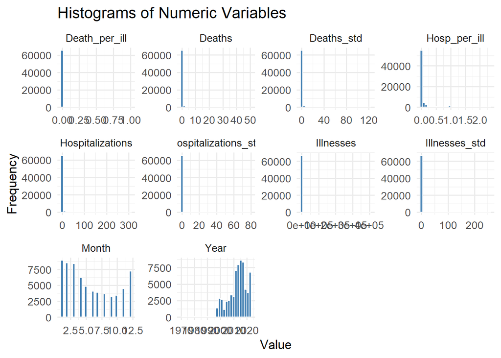

```r
# 1. Define numeric variables
num_vars <- c(
  "Year", "Month",
  "Illnesses", "Hospitalizations", "Deaths",
  "Illnesses_std", "Hospitalizations_std", "Deaths_std",
  "Hosp_per_ill", "Death_per_ill"
)

# 2. Reshape the numeric data for plotting
num_vars_long <- clean_df %>%
  select(all_of(num_vars)) %>%
  pivot_longer(everything(), names_to = "variable", values_to = "value")

# 3. Plot histograms for each numeric variable
ggplot(num_vars_long, aes(x = value)) +
  geom_histogram(bins = 30, fill = "steelblue", color = "white") +
  facet_wrap(~ variable, scales = "free") +
  theme_minimal(base_size = 13) +
  labs(
    title = "Histograms of Numeric Variables",
    x = "Value",
    y = "Frequency"
  )
```

```r
# 4. Save to repo
ggsave(
  filename = "Histogram_numeric_vars.png",  # file name
  width = 8, height = 5, units = "in",          # size in inches
  dpi = 300                                     # resolution for publication-quality image
)
```

It appears that all except Month and Year might need to be log-transformed to achieve are more normal distribution

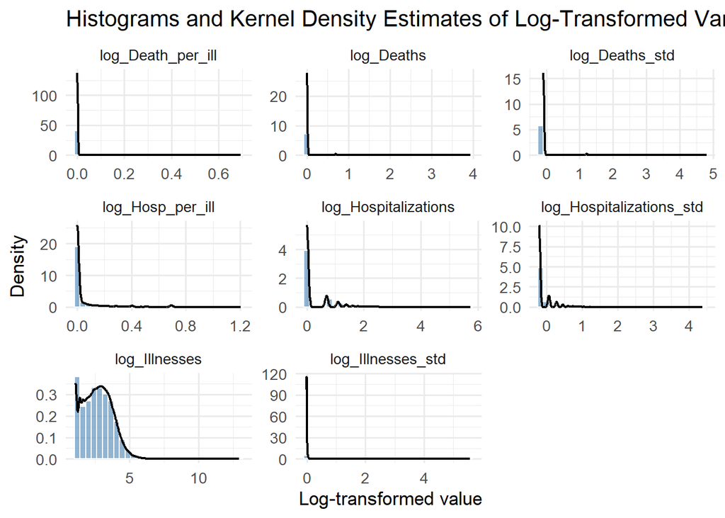

```r
# 1. Define variables to log-transform
vars_to_log <- c(
  "Illnesses", "Hospitalizations", "Deaths",
  "Illnesses_std", "Hospitalizations_std", "Deaths_std",
  "Hosp_per_ill", "Death_per_ill"
)

# 2. Apply log transformation (add small constant to handle zeros)
clean_df <- clean_df %>%
  mutate(
    across(
      all_of(vars_to_log),
      ~ log(. + 1),                # add 1 to avoid log(0)
      .names = "log_{.col}"        # create new columns prefixed with 'log_'
    )
  )

# 3. Reshape data for easy plotting
log_vars_long <- clean_df %>%
  select(starts_with("log_")) %>%
  pivot_longer(everything(), names_to = "variable", values_to = "value")

# 4. Plot histograms for each log variable and add a kernel density estimation
ggplot(log_vars_long, aes(x = value)) +
  # histogram as density
  geom_histogram(aes(y = after_stat(density)),
                 bins = 30, fill = "steelblue", color = "white", alpha = 0.6) +
  # kernel density estimate
  geom_density(linewidth = 0.8) +
  facet_wrap(~ variable, scales = "free") +
  theme_minimal(base_size = 13) +
  labs(
    title = "Histograms and Kernel Density Estimates of Log-Transformed Variables",
    x = "Log-transformed value",
    y = "Density"
  )
```

```r
# 5. Save to repo
ggsave(
  filename = "Histograms_and_KDE_of_log_vars.png",  # file name
  width = 8, height = 5, units = "in",          # size in inches
  dpi = 300                                     # resolution for publication-quality image
)
```

Interpretation:

- Most outbreaks are small, with few hospitalizations or deaths.
- Log scale reveals the shape of the bulk of the data without extreme outbreaks dominating the plot.
- There is a long tail of very large outbreaks for illnesses, which may represent epidemics or reporting anomalies.

## III. Top Contributing Factors

### Etiologies

#### a. Top 50 Etiologies Resulting in the Most Total Number of Illnesses

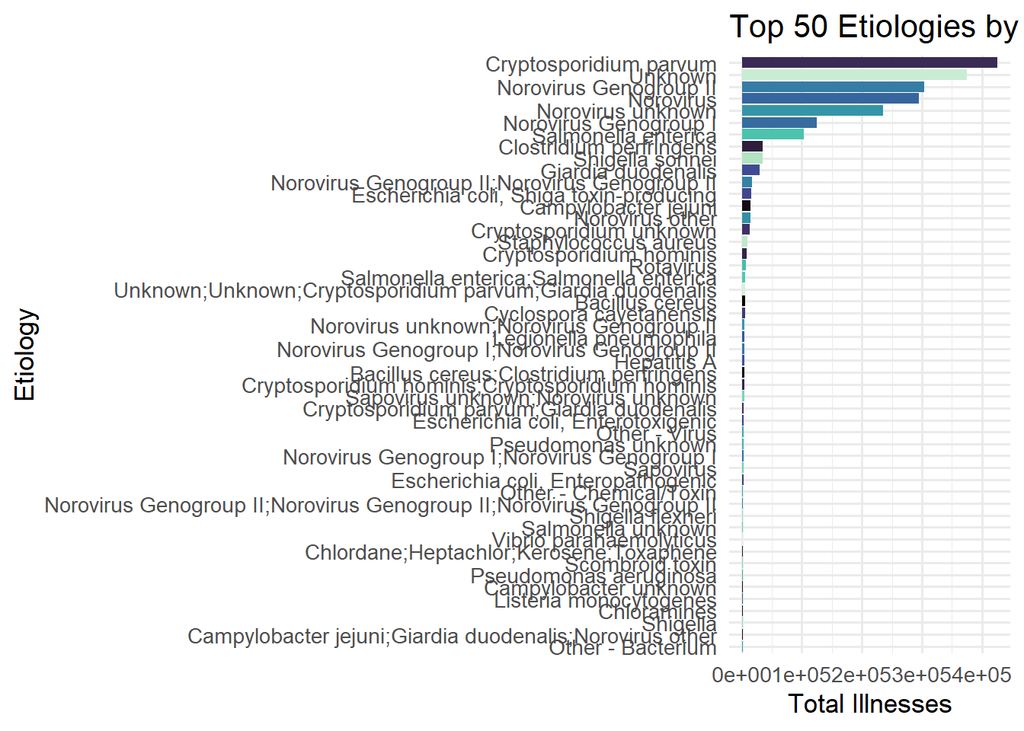

```r
# 1. Isolate top 50 etiologies by total illnesses
top_etiology <- clean_df %>%
  group_by(Etiology) %>%
  summarise(total_illnesses = sum(Illnesses, na.rm = TRUE)) %>%
  arrange(desc(total_illnesses)) %>%
  slice_head(n = 50)

# 2. Plot
ggplot(top_etiology,
       aes(y = reorder(Etiology, total_illnesses),
           x = total_illnesses,
           fill = Etiology)) +
  geom_col(show.legend = FALSE) +
  scale_fill_viridis_d(option = "mako") +
  theme_minimal(base_size = 13) +
  labs(
    title = "Top 50 Etiologies by Total Illnesses",
    x = "Total Illnesses",
    y = "Etiology"
  )
```

```r
# 3. Save to repo
ggsave(
  filename = "Top_etiologies_by_total_illnesses.png",  # file name
  width = 12, height = 12, units = "in",          # size in inches
  dpi = 300                                     # resolution for publication-quality image
)
```

#### b. Top 50 Etiologies by Hospitalization Severity

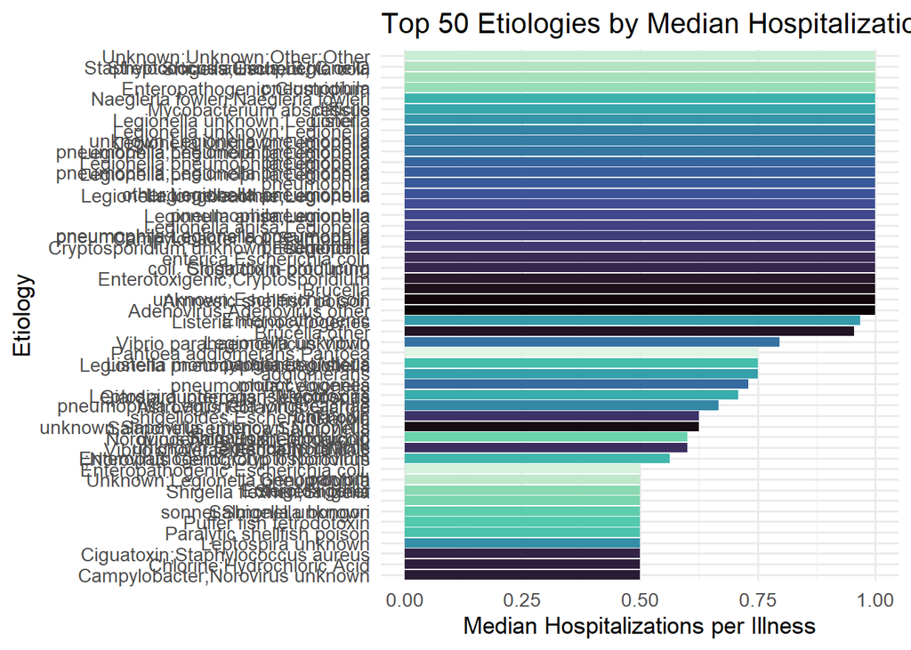

```r
# 1. Calculate median severity ratios by etiology
severity <- clean_df %>%
  group_by(Etiology) %>%
  summarise(
    median_hosp_per_ill = median(Hosp_per_ill, na.rm = TRUE)
  ) %>%
  arrange(desc(median_hosp_per_ill)) %>%
  slice_head(n = 50)

# 2. Clean up long labels for plotting
library(stringr)

severity <- severity %>%
  mutate(Etiology_lab = str_wrap(Etiology, width = 35))  # wrap long names

# 3. Make the plot object
ggplot(
  severity,
  aes(
    x = median_hosp_per_ill,
    y = reorder(Etiology_lab, median_hosp_per_ill),
    fill = Etiology
  )
) +
  geom_col(show.legend = FALSE) +
  scale_fill_viridis_d(option = "mako") +
  theme_minimal(base_size = 13) +
  labs(
    title = "Top 50 Etiologies by Median Hospitalizations per Illness",
    x = "Median Hospitalizations per Illness",
    y = "Etiology"
  )
```

```r
# 4. Save to file
ggsave(
  filename = "Top_etiologies_by_median_hospitalizations_per_illness.png",
  width = 12, height = 12,
  units = "in",
  dpi = 300
)
```

Etiologies which have a hospitalization/illness rate >50%

```r
# Identify etiologies where median Hosp_per_ill > 0.5 (i.e., >50%)
high_severity <- severity %>%
  filter(median_hosp_per_ill > 0.5)

# View results
high_severity
```

```
## # A tibble: 39 × 3
##    Etiology                                     median_hosp_per_ill Etiology_lab
##    <chr>                                                      <dbl> <chr>
##  1 Adenovirus;Adenovirus other                                    1 "Adenovirus…
##  2 Amnesic shellfish poison                                       1 "Amnesic sh…
##  3 Brucella                                                       1 "Brucella"
##  4 Campylobacter coli;Salmonella enterica;Esch…                   1 "Campylobac…
##  5 Clostridium botulinum                                          1 "Clostridiu…
##  6 Cryptosporidium unknown;Escherichia coli, S…                   1 "Cryptospor…
##  7 Legionella                                                     1 "Legionella"
##  8 Legionella anisa;Legionella pneumophila                        1 "Legionella…
##  9 Legionella anisa;Legionella pneumophila;Leg…                   1 "Legionella…
## 10 Legionella longbeachae;Legionella pneumophi…                   1 "Legionella…
## # ℹ 29 more rows
```

#### d. Top 50 Etiologies by Death Severity

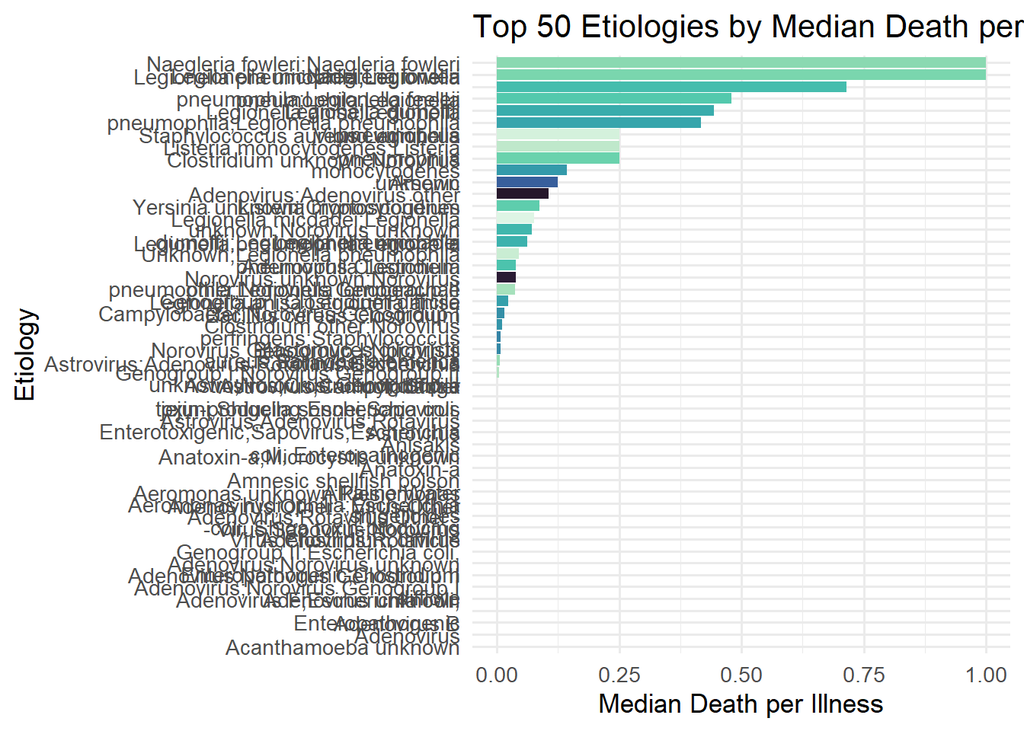

```r
# 1. Calculate median severity ratios by etiology
severity <- clean_df %>%
  group_by(Etiology) %>%
  summarise(
    median_death_per_ill = median(Death_per_ill, na.rm = TRUE)
  ) %>%
  arrange(desc(median_death_per_ill)) %>%
  slice_head(n = 50)

# 2. Clean up long labels for plotting
library(stringr)

severity <- severity %>%
  mutate(Etiology_lab = str_wrap(Etiology, width = 35))  # wrap long names

# 3. Make the plot object
ggplot(
  severity,
  aes(
    x = median_death_per_ill,
    y = reorder(Etiology_lab, median_death_per_ill),
    fill = Etiology
  )
) +
  geom_col(show.legend = FALSE) +
  scale_fill_viridis_d(option = "mako") +
  theme_minimal(base_size = 13) +
  labs(
    title = "Top 50 Etiologies by Median Death per Illness",
    x = "Median Death per Illness",
    y = "Etiology"
  )
```

```r
# 4. Save to file
ggsave(
  filename = "Top_etiologies_by_median_death_per_illness.png",
  width = 12, height = 12,
  units = "in",
  dpi = 300
)
```

Etiologies with a high death/illness rate, say above 20%

```r
# Identify etiologies where median Death_per_ill > 0.5 (i.e., >20%)
high_lethality <- severity %>%
  filter(median_death_per_ill > 0.20)

# View results
high_lethality
```

```
## # A tibble: 9 × 3
##   Etiology                                     median_death_per_ill Etiology_lab
##   <chr>                                                       <dbl> <chr>
## 1 Naegleria fowleri                                           1     "Naegleria …
## 2 Naegleria fowleri;Naegleria fowleri                         1     "Naegleria …
## 3 Legionella micdadei;Legionella pneumophila;…                0.714 "Legionella…
## 4 Legionella pneumophila;Legionella pneumophi…                0.48  "Legionella…
## 5 Legionella dumoffii                                         0.444 "Legionella…
## 6 Legionella anisa;Legionella pneumophila                     0.417 "Legionella…
## 7 Listeria monocytogenes;Listeria monocytogen…                0.25  "Listeria m…
## 8 Staphylococcus aureus;Legionella pneumophila                0.25  "Staphyloco…
## 9 Vibrio vulnificus                                           0.25  "Vibrio vul…
```

### Settings

#### a. Top 50 Settings in Which Illnesses Occur

[figure not shown]

```r
# Isolate top 50 settings by total illnesses
top_setting <- clean_df %>%
  group_by(Setting) %>%
  summarise(total_illnesses = sum(Illnesses, na.rm = TRUE)) %>%
  arrange(desc(total_illnesses)) %>%
  slice_head(n = 50)

# 2. Plot
ggplot(top_setting,
       aes(y = reorder(Setting, total_illnesses),
           x = total_illnesses,
           fill = Setting)) +
  geom_col(show.legend = FALSE) +
  scale_fill_viridis_d(option = "C") +
  theme_minimal(base_size = 13) +
  labs(
    title = "Top 50 Settings by Total Illnesses",
    x = "Total Illnesses",
    y = "Setting"
  )
```

```r
# 3. Save to repo
ggsave(
  filename = "Top_settings_by_total_illnesses.png",
  width = 12, height = 12, units = "in", dpi = 200
)
```

### Primary Mode

#### a. Most Risky Primary Mode of Outbreak

```r
primary_mode_summary <- clean_df %>%
  group_by(Primary_mode) %>%
  summarise(
    median_illnesses     = median(Illnesses, na.rm = TRUE),
    mean_hosp_per_ill    = mean(Hosp_per_ill, na.rm = TRUE),
    mean_death_per_ill   = mean(Death_per_ill, na.rm = TRUE),
    n_outbreaks          = n(),   # gives context about reporting volume
    .groups = "drop"
  ) %>%
  arrange(desc(median_illnesses))

primary_mode_summary
```

```
## # A tibble: 6 × 5
##   Primary_mode median_illnesses mean_hosp_per_ill mean_death_per_ill n_outbreaks
##   <chr>                   <dbl>             <dbl>              <dbl>       <int>
## 1 Person-to-p…               21            0.0243            0.00128       32414
## 2 Environment…               10            0.101             0.00436         132
## 3 Water                       9            0.239             0.0300         3106
## 4 Indetermina…                8            0.0600            0.00201        5677
## 5 Food                        7            0.0648            0.00225       24729
## 6 Animal cont…                6            0.163             0.00230         655
```

Plot of illnesses by primary mode

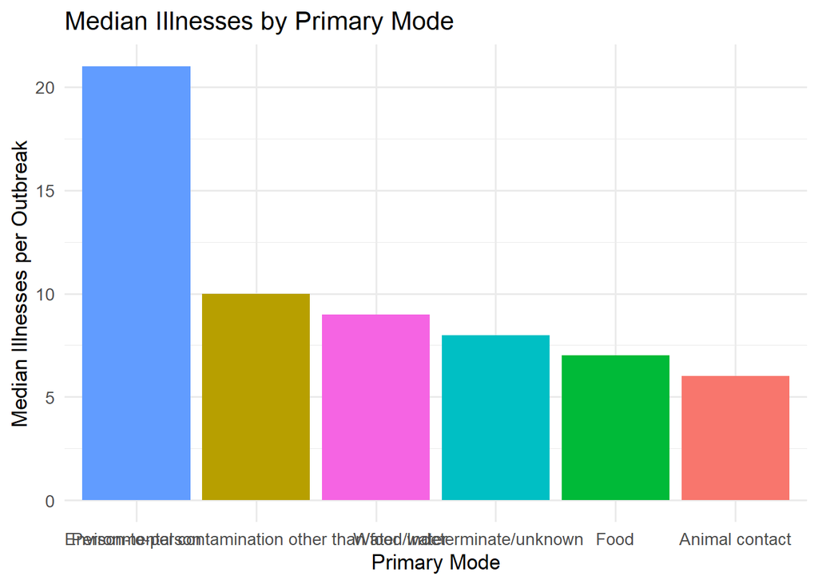

```r
# Plot median illnesses by primary mode
ggplot(primary_mode_summary, aes(x = reorder(Primary_mode, -median_illnesses), y = median_illnesses, fill = Primary_mode)) +
  geom_col(show.legend = FALSE) +
  theme_minimal(base_size = 13) +
  labs(
    title = "Median Illnesses by Primary Mode",
    x = "Primary Mode",
    y = "Median Illnesses per Outbreak"
  )
```

```r
# Save
ggsave("Median_Illnesses_by_Primary_Mode.png", width = 8, height = 5, units = "in", dpi = 300)
```

Plot of hospitalizations/illnesses by primary mode

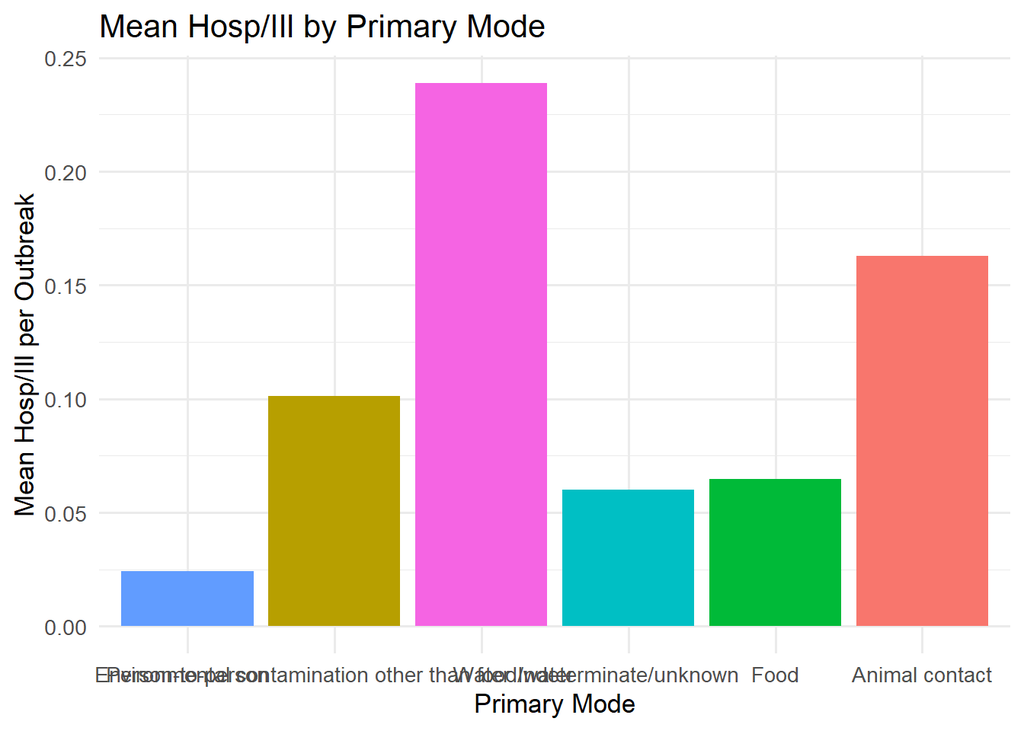

```r
ggplot(primary_mode_summary, aes(x = reorder(Primary_mode, -median_illnesses), y = mean_hosp_per_ill, fill = Primary_mode)) +
  geom_col(show.legend = FALSE) +
  theme_minimal(base_size = 13) +
  labs(
    title = "Mean Hosp/Ill by Primary Mode",
    x = "Primary Mode",
    y = "Mean Hosp/Ill per Outbreak"
  )
```

```r
# Save
ggsave("Mean_Hosp_per_Ill_by_Primary_Mode.png", width = 8, height = 5, units = "in", dpi = 300)
```

Plot of deaths/illnesses by primary mode

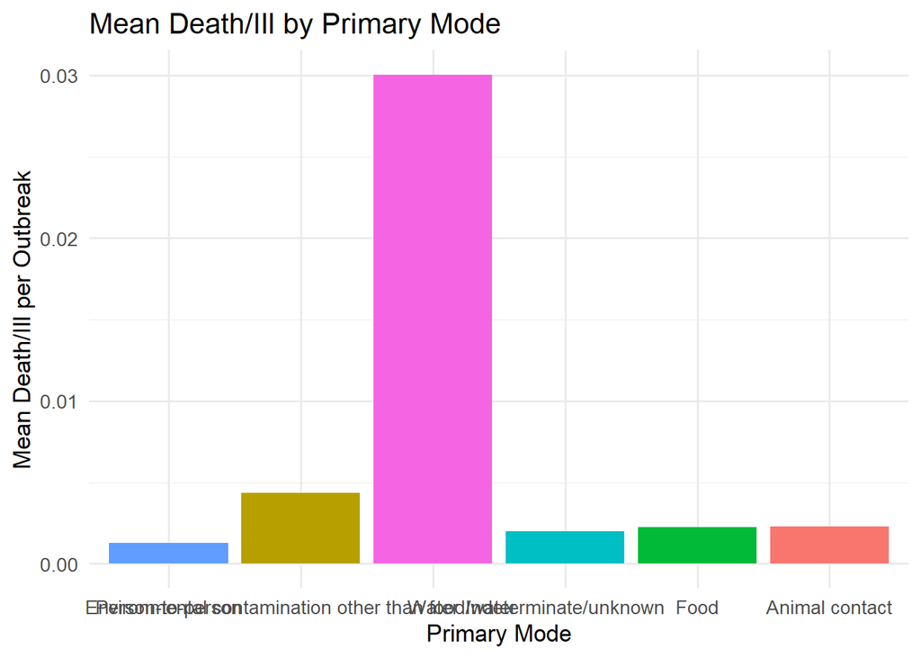

```r
ggplot(primary_mode_summary, aes(x = reorder(Primary_mode, -median_illnesses), y = mean_death_per_ill, fill = Primary_mode)) +
  geom_col(show.legend = FALSE) +
  theme_minimal(base_size = 13) +
  labs(
    title = "Mean Death/Ill by Primary Mode",
    x = "Primary Mode",
    y = "Mean Death/Ill per Outbreak"
  )
```

```r
# Save
ggsave("Mean_Death_per_Ill_by_Primary_Mode.png", width = 8, height = 5, units = "in", dpi = 300)
```

## Spatial Trends

### a. Median Illness by State

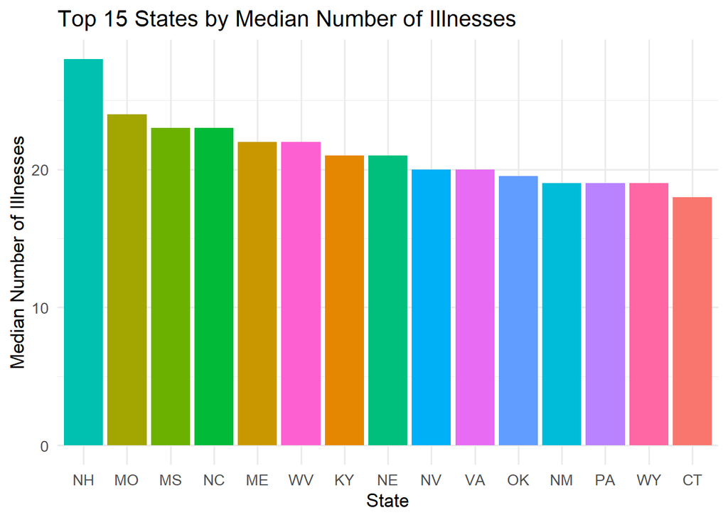

```r
# 1. Compute median illnesses per state
geo <- clean_df %>%
  group_by(State_abbr) %>%
  summarise(median_illnesses = median(Illnesses, na.rm = TRUE)) %>%
  arrange(desc(median_illnesses)) %>%
  slice_head(n = 15)

# 2. Plot top 15 states by median illnesses
ggplot(
  geo,
  aes(
    x = reorder(State_abbr, -median_illnesses),
    y = median_illnesses,
    fill = State_abbr
  )
) +
  geom_col(show.legend = FALSE) +
  theme_minimal(base_size = 13) +
  labs(
    title = "Top 15 States by Median Number of Illnesses",
    x = "State",
    y = "Median Number of Illnesses"
  )
```

```r
# 3. Save the plot
ggsave(
  filename = "Top_15_States_by_Median_Illnesses.png",
  width = 10, height = 5, units = "in", dpi = 300
)
```

### b. Median Yearly Illness by State

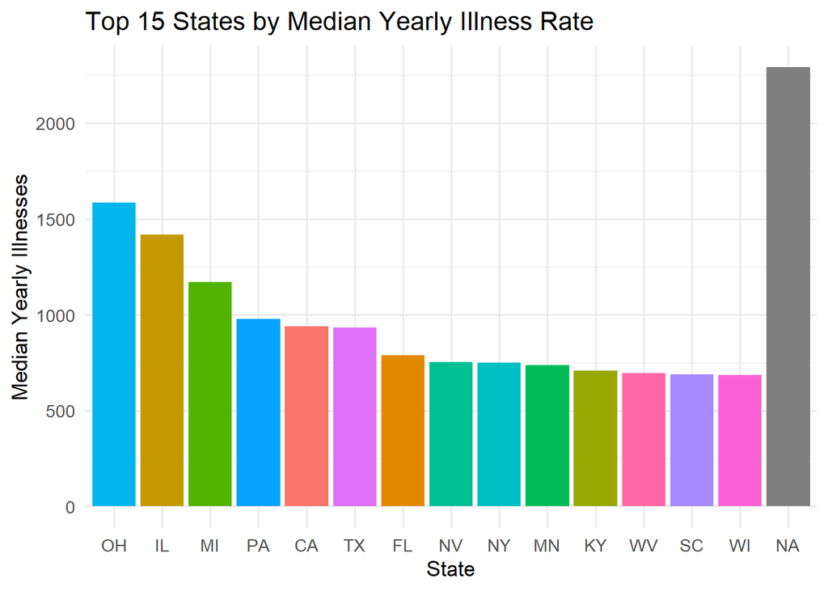

```r
# 1. Compute total illnesses per state-year, then median yearly illness rate per state
yearly_geo <- clean_df %>%
  group_by(State_abbr, Year) %>%
  summarise(yearly_illnesses = sum(Illnesses, na.rm = TRUE), .groups = "drop") %>%
  group_by(State_abbr) %>%
  summarise(median_yearly_illnesses = median(yearly_illnesses, na.rm = TRUE)) %>%
  arrange(desc(median_yearly_illnesses)) %>%
  slice_head(n = 15)

# 2. Plot top 15 states by median yearly illness rate
ggplot(
  yearly_geo,
  aes(
    x = reorder(State_abbr, -median_yearly_illnesses),
    y = median_yearly_illnesses,
    fill = State_abbr
  )
) +
  geom_col(show.legend = FALSE) +
  theme_minimal(base_size = 13) +
  labs(
    title = "Top 15 States by Median Yearly Illness Rate",
    x = "State",
    y = "Median Yearly Illnesses"
  )
```

```r
# 3. Save the plot
ggsave(
  filename = "Top_15_States_by_Median_Yearly_Illnesses.png",
  width = 10, height = 5, units = "in", dpi = 300
)
```

### c. Mean Yearly Hospitalization/Illness Rate by State

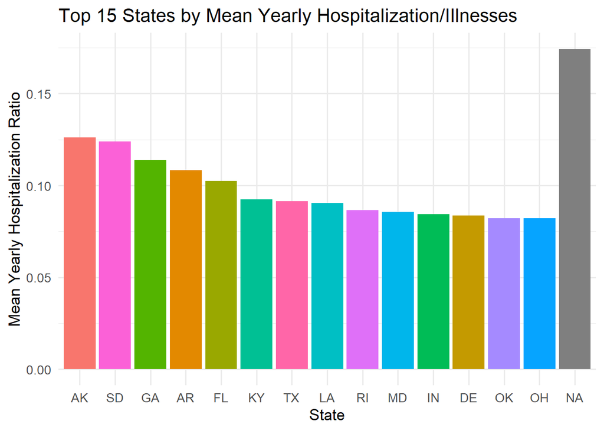

```r
# 1. Compute mean Hosp_per_ill per state-year, then mean across years per state
yearly_hosp_ratio <- clean_df %>%
  group_by(State_abbr, Year) %>%
  summarise(yearly_hosp_ratio = mean(Hosp_per_ill, na.rm = TRUE), .groups = "drop") %>%
  group_by(State_abbr) %>%
  summarise(mean_yearly_hosp_ratio = mean(yearly_hosp_ratio, na.rm = TRUE)) %>%
  arrange(desc(mean_yearly_hosp_ratio)) %>%
  slice_head(n = 15)

# 2. Plot top 15 states by mean yearly hospitalization ratio
ggplot(
  yearly_hosp_ratio,
  aes(
    x = reorder(State_abbr, -mean_yearly_hosp_ratio),
    y = mean_yearly_hosp_ratio,
    fill = State_abbr
  )
) +
  geom_col(show.legend = FALSE) +
  theme_minimal(base_size = 13) +
  labs(
    title = "Top 15 States by Mean Yearly Hospitalization/Illnesses",
    x = "State",
    y = "Mean Yearly Hospitalization Ratio"
  )
```

```r
# 3. Save plot
ggsave(
  filename = "Top_15_States_by_Mean_Yearly_Hosp_per_Ill.png",
  width = 10, height = 5, units = "in", dpi = 300
)
```

### d. Mean Yearly Deaths/Illness Rate by State

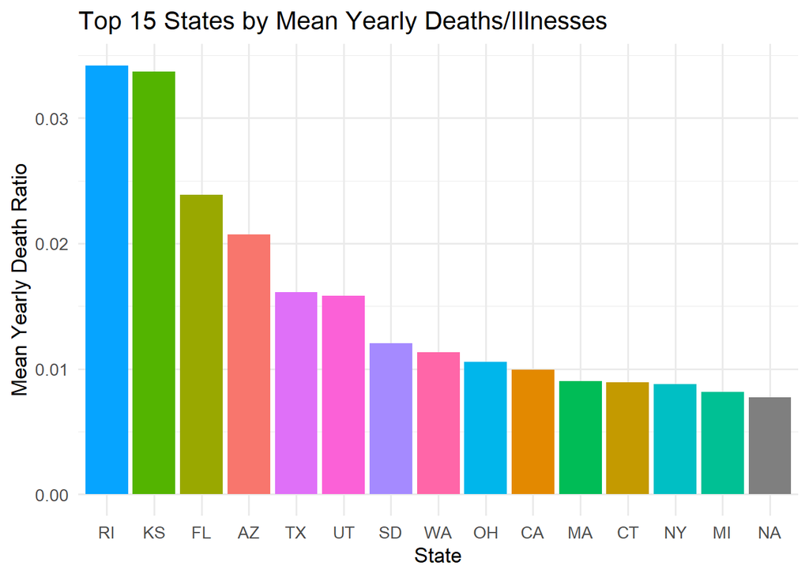

```r
# 1. Compute mean Death_per_ill per state-year, then mean across years per state
yearly_death_ratio <- clean_df %>%
  group_by(State_abbr, Year) %>%
  summarise(yearly_death_ratio = mean(Death_per_ill, na.rm = TRUE), .groups = "drop") %>%
  group_by(State_abbr) %>%
  summarise(mean_yearly_death_ratio = mean(yearly_death_ratio, na.rm = TRUE)) %>%
  arrange(desc(mean_yearly_death_ratio)) %>%
  slice_head(n = 15)

# 2. Plot top 15 states by mean yearly death ratio
ggplot(
  yearly_death_ratio,
  aes(
    x = reorder(State_abbr, -mean_yearly_death_ratio),
    y = mean_yearly_death_ratio,
    fill = State_abbr
  )
) +
  geom_col(show.legend = FALSE) +
  theme_minimal(base_size = 13) +
  labs(
    title = "Top 15 States by Mean Yearly Deaths/Illnesses",
    x = "State",
    y = "Mean Yearly Death Ratio"
  )
```

```r
# 3. Save the plot
ggsave(
  filename = "Top_15_States_by_Mean_Yearly_Death_per_Ill.png",
  width = 10, height = 5, units = "in", dpi = 300
)
```

## Temporal Trends

### a. Seasonal Decomposition

Median illness by season across all types of outbreaks and dates

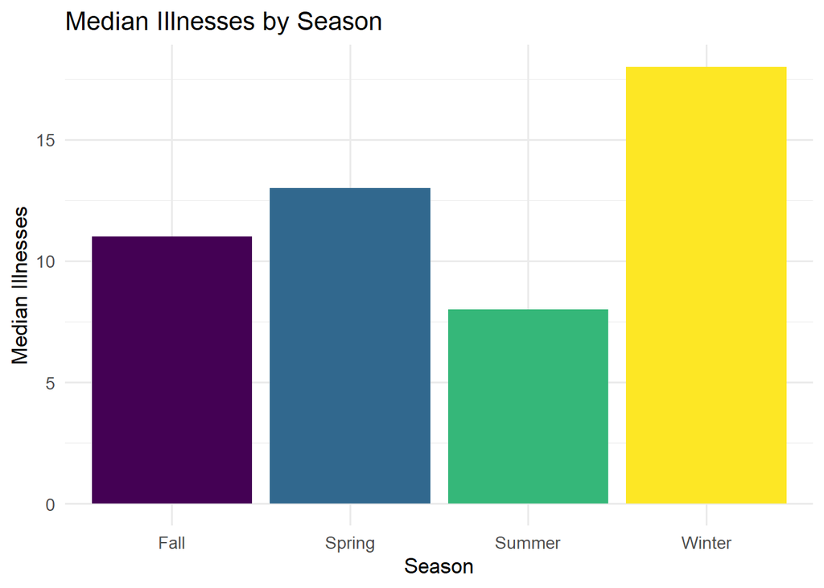

```r
# 1. Median illnesses by season
seasonal <- clean_df %>%
  group_by(Season) %>%
  summarise(median_illnesses = median(Illnesses, na.rm = TRUE)) %>%
  ungroup()

# 2. Plot
ggplot(seasonal, aes(x = Season, y = median_illnesses, fill = Season)) +
  geom_col(show.legend = FALSE) +
  scale_fill_viridis_d() +
  theme_minimal(base_size = 13) +
  labs(
    title = "Median Illnesses by Season",
    x = "Season",
    y = "Median Illnesses"
  )
```

```r
# 3. Save to repo
ggsave(
  filename = "Median_illnesses_by_season.png",  # file name
  width = 8, height = 5, units = "in",          # size in inches
  dpi = 300                                     # resolution for publication-quality image
)
```

### b. Monthly Decomposition

**Plot of total illnesses over time (log transformed)**

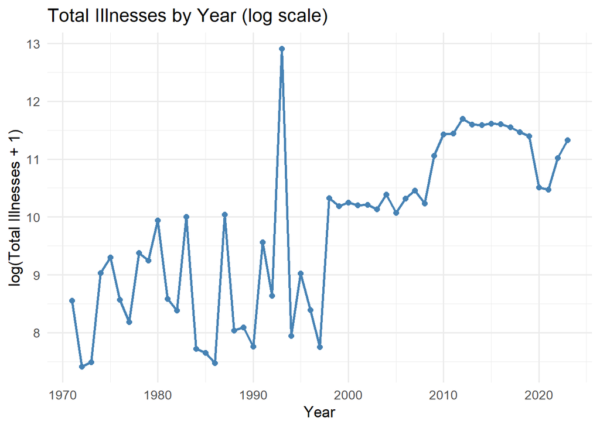

```r
# 1. Sum of illnesses per year
yearly <- clean_df %>%
  group_by(Year) %>%
  summarise(total_illnesses = sum(Illnesses, na.rm = TRUE)) %>%
  ungroup()

# 2. Plot (log scale)
ggplot(yearly, aes(x = Year, y = log1p(total_illnesses))) +
  geom_line(color = "steelblue", linewidth = 1) +
  geom_point(color = "steelblue", size = 2) +
  theme_minimal(base_size = 13) +
  labs(
    title = "Total Illnesses by Year (log scale)",
    x = "Year",
    y = "log(Total Illnesses + 1)"
  )
```

```r
# 3. Save to repo
ggsave(
  filename = "Log_total_illnesses_by_year.png",  # file name
  width = 8, height = 5, units = "in",          # size in inches
  dpi = 300                                     # resolution for publication-quality image
)
```

Clearly, there’s an outlier; let’s identify it:

```r
# 1. Filter all outbreaks from 1993-03
march_1993 <- clean_df %>%
  filter(Year == 1993, Month == 3)

# 2. See summary of illnesses and key variables
march_1993 %>%
  summarise(
    total_illnesses = sum(Illnesses, na.rm = TRUE),
    n_outbreaks = n(),
    states_involved = n_distinct(State_abbr),
    top_state = State_abbr[which.max(Illnesses)],
    primary_mode = names(sort(table(Primary_mode), decreasing = TRUE))[1]
  )
```

```
## # A tibble: 1 × 5
##   total_illnesses n_outbreaks states_involved top_state primary_mode
##             <dbl>       <int>           <int> <chr>     <chr>
## 1          403114           4               3 WI        Water
```

```r
# 3. Identify which state it occurred in
march_1993 %>%
  group_by(State_abbr, Etiology) %>%
  summarise(
    total_ill = sum(Illnesses, na.rm = TRUE),
    hosp_per_ill = sum(Hosp_per_ill),
    deaths_per_ill = sum(Death_per_ill)) %>%
  arrange(desc(total_ill)) %>%
  slice_head(n = 10)
```

```
## # A tibble: 4 × 5
## # Groups:   State_abbr [3]
##   State_abbr Etiology               total_ill hosp_per_ill deaths_per_ill
##   <chr>      <chr>                      <dbl>        <dbl>          <dbl>
## 1 MN         Pseudomonas aeruginosa         6            0       0
## 2 PA         Unknown                       65            0       0
## 3 PA         Copper                        43            0       0
## 4 WI         Cryptosporidium parvum    403000            0       0.000124
```

This date 1993-03-01 had 403,114 illness cases. According to a google search, this incident was caused by the 1993 Milwaukee Cryptosporidium waterborne outbreak, which sickened over 400,000 people — the largest waterborne disease outbreak in U.S. history.

**Plot of total hospitalizations over time (log transformed)**

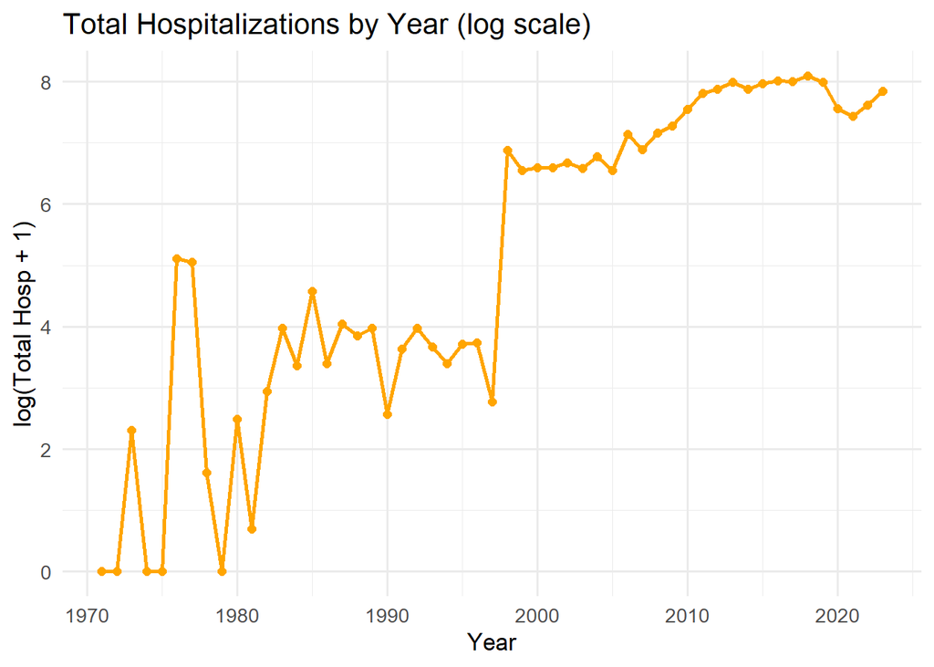

```r
# 1. Sum of hospitalizations per year
yearly <- clean_df %>%
  group_by(Year) %>%
  summarise(total_hosp = sum(Hospitalizations, na.rm = TRUE)) %>%
  ungroup()

# 2. Plot (log scale)
ggplot(yearly, aes(x = Year, y = log1p(total_hosp))) +
  geom_line(color = "orange", linewidth = 1) +
  geom_point(color = "orange", size = 2) +
  theme_minimal(base_size = 13) +
  labs(
    title = "Total Hospitalizations by Year (log scale)",
    x = "Year",
    y = "log(Total Hosp + 1)"
  )
```

```r
# 3. Save to repo
ggsave(
  filename = "Log_total_hosp_by_year.png",  # file name
  width = 8, height = 5, units = "in",          # size in inches
  dpi = 300                                     # resolution for publication-quality image
)
```

**Plot of total deaths over time (log transformed)**

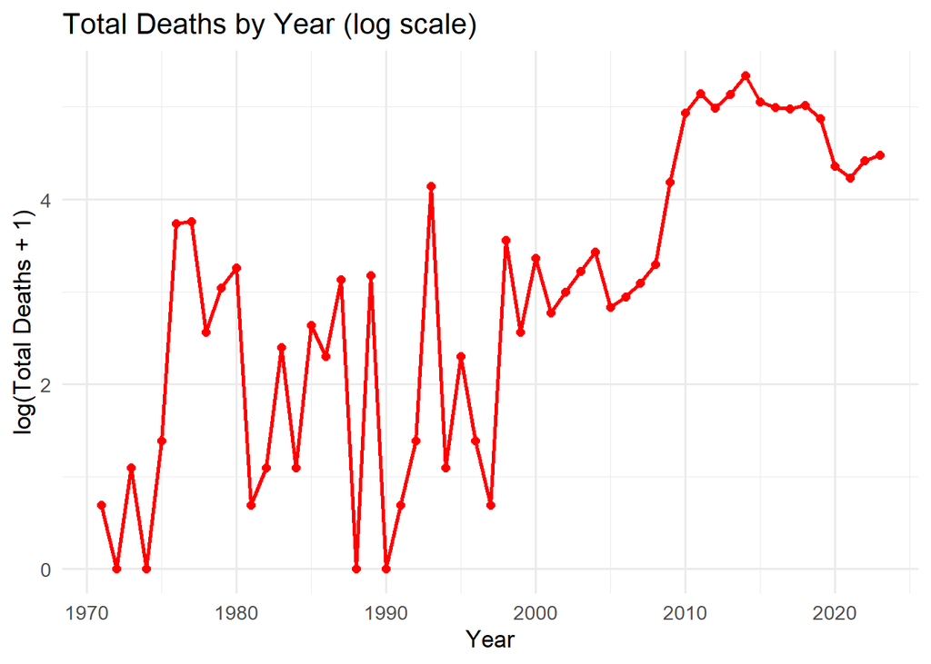

```r
# 1. Sum of hospitalizations per year
yearly <- clean_df %>%
  group_by(Year) %>%
  summarise(total_deaths = sum(Deaths, na.rm = TRUE)) %>%
  ungroup()

# 2. Plot (log scale)
ggplot(yearly, aes(x = Year, y = log1p(total_deaths))) +
  geom_line(color = "red", linewidth = 1) +
  geom_point(color = "red", size = 2) +
  theme_minimal(base_size = 13) +
  labs(
    title = "Total Deaths by Year (log scale)",
    x = "Year",
    y = "log(Total Deaths + 1)"
  )
```

```r
# 3. Save to repo
ggsave(
  filename = "Log_total_deaths_by_year.png",  # file name
  width = 8, height = 5, units = "in",          # size in inches
  dpi = 300                                     # resolution for publication-quality image
)
```

While total hospitalizations and deaths have increased over time, this may be due to increasing population size. So, it may be better to assess the ratio of hospitalizations/illnesses and deaths/illnesses over time.

**Plot of hospitalizations per illnesses over time**

```r
# 1. Monthly tends in hospitalizations per illnesses
monthly_trends <- clean_df %>%
  group_by(Year, Month) %>%
  summarise(total_hosp_per_ill = sum(Hosp_per_ill, na.rm = TRUE)) %>%
  mutate(Date = as.Date(paste(Year, Month, "01", sep = "-")))
```

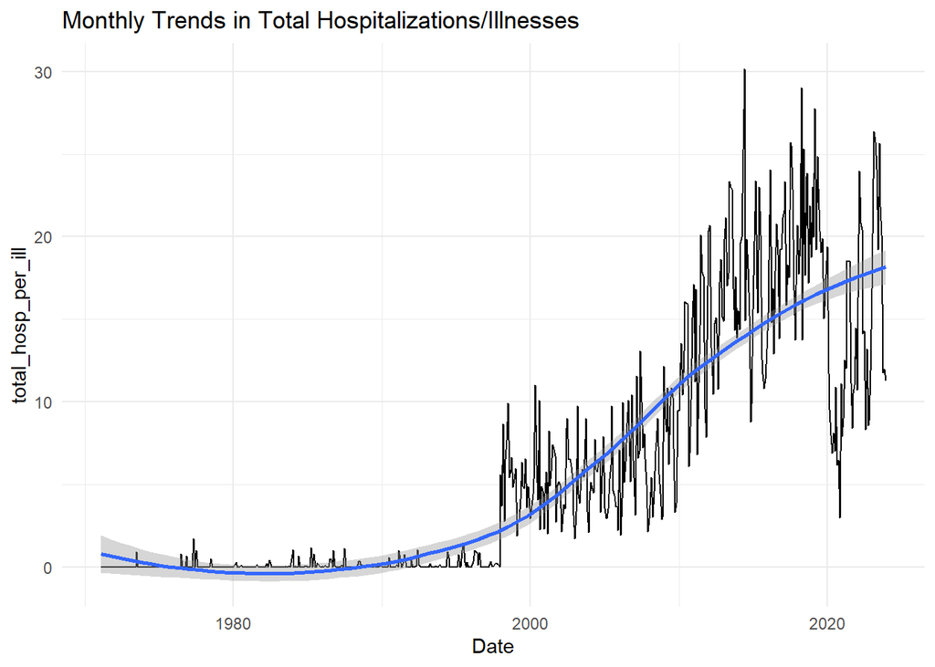

```r
# 2. Plot of total illnesses
ggplot(monthly_trends, aes(x = Date, y = total_hosp_per_ill)) +
  geom_line() +
  theme_minimal() +
  geom_smooth() +
  labs(title = "Monthly Trends in Total Hospitalizations/Illnesses")
```

```r
# 3. Save to repo
ggsave(
  filename = "Monthly_trend_total_hosp_per_ill.png",
  width = 10, height = 5, units = "in", dpi = 300
)
```

**Plot of deaths per illnesses over time**

```r
# 1. Monthly tends in deaths per illnesses
monthly_trends <- clean_df %>%
  group_by(Year, Month) %>%
  summarise(total_death_per_ill = sum(Death_per_ill, na.rm = TRUE)) %>%
  mutate(Date = as.Date(paste(Year, Month, "01", sep = "-")))
```

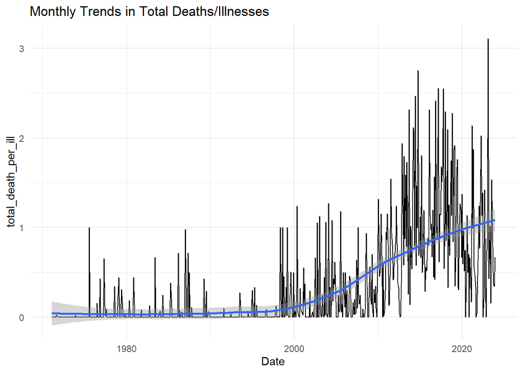

```r
# 2. Plot of total illnesses
ggplot(monthly_trends, aes(x = Date, y = total_death_per_ill)) +
  geom_line() +
  theme_minimal() +
  geom_smooth() +
  labs(title = "Monthly Trends in Total Deaths/Illnesses")
```

```r
# 3. Save to repo
ggsave(
  filename = "Monthly_trend_total_death_per_ill.png",
  width = 10, height = 5, units = "in", dpi = 300
)
```

It seems like illnesses are becoming more severe over time, especially since 2000. Or, this could be reflecting an increased rate or improved system for reporting these metrics.